# Verslag

Sanne, Pim, Milain

1/9/2020

```r
knitr::opts_chunk$set(echo = TRUE)
library(edgeR)
fDir <-  "C:\\Users\\Queuebee\\Documents\\GitHub\\Course6Tutor\\R"
fName <- "\\data\\WCFS1_cnts.txt"

cnts <- read.delim(paste0(fDir,fName), comment.char="#")
WCFS1_anno <- read.delim2("data\\WCFS1_anno.txt")
### used for topTags identification
row.names(cnts) <- cnts[,"ID"]

# makes groups names
exp <- c("WCFS1.glc","WCFS1.glc","WCFS1.rib","WCFS1.rib")

# makes a factor of those group names
group <- factor(exp)

# makes a DGE list for easy editing
# using only the counts( colom 2 to 5)
# using the factors as groups
y <- DGEList(counts=cnts[,2:5],group=group)
```

# Normalise counts

Trimmed mean of M values : remove lowest and highest values (percentile) and calculate mean

```r
y <- calcNormFactors(y, method="TMM" )
```

# Check statistics

```r
print("Count statistics")
```

```
## [1] "Count statistics"
```

```r
print(summary(y$counts))
```

```
##   WCFS1.glc.1      WCFS1.glc.2      WCFS1.rib.1      WCFS1.rib.2
##  Min.   :     0   Min.   :     0   Min.   :     0   Min.   :     0
##  1st Qu.:   115   1st Qu.:   120   1st Qu.:   129   1st Qu.:   144
##  Median :   610   Median :   639   Median :   634   Median :   684
##  Mean   :  3666   Mean   :  3818   Mean   :  3611   Mean   :  3778
##  3rd Qu.:  2362   3rd Qu.:  2422   3rd Qu.:  2331   3rd Qu.:  2538
##  Max.   :304949   Max.   :348490   Max.   :299861   Max.   :351280
```

```r
print(y$samples)
```

```
##                 group lib.size norm.factors
## WCFS1.glc.1 WCFS1.glc 11206738    1.0348799
## WCFS1.glc.2 WCFS1.glc 11671184    1.0278238
## WCFS1.rib.1 WCFS1.rib 11039613    0.9468222
## WCFS1.rib.2 WCFS1.rib 11549518    0.9929399
```

# Create design matrix to let R know what is what

```r
design <- model.matrix(~0+group, data=y$samples)
colnames(design) <- levels(y$samples$group)
print(design)
```

```
##             WCFS1.glc WCFS1.rib
## WCFS1.glc.1         1         0
## WCFS1.glc.2         1         0
## WCFS1.rib.1         0         1
## WCFS1.rib.2         0         1
## attr(,"assign")
## [1] 1 1
## attr(,"contrasts")
## attr(,"contrasts")$group
## [1] "contr.treatment"
```

# Estimate Dispersion

method (low-level function) used to estimated the trended dispersions. Possible values are “auto” (default) switch to “bin.spline” method if the number of genes is great than 200 and “power” method otherwise)

```r
#y <- estimateDisp(y, design)

y <- estimateGLMCommonDisp(y,design)
y <- estimateGLMTrendedDisp(y,design, method="power")
y <- estimateGLMTagwiseDisp(y,design)
```

# Plot results

MDS :Plot samples on a two-dimensional scatterplot so that distances on the plot approximate the typical log2 fold changes between the samples. BCV : Plot the genewise biological coefficient of variation (BCV) against gene abundance (in log2 counts per million).

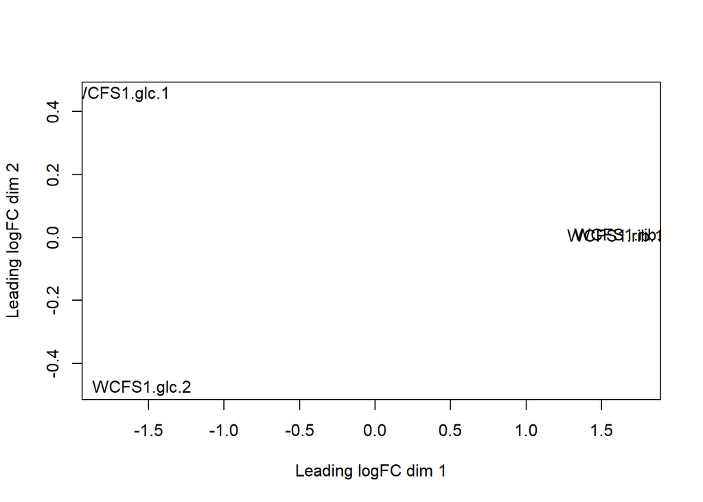

```r
plotMDS(y)
```

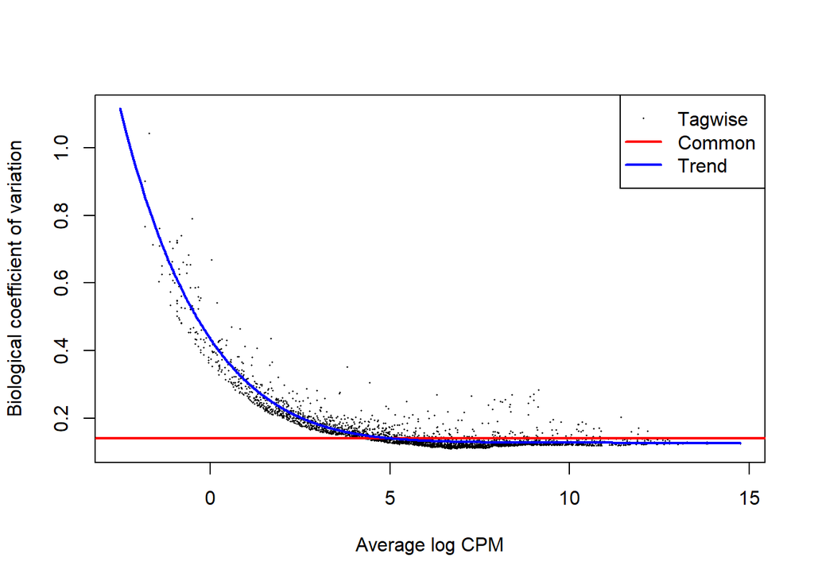

```r
plotBCV(y)
```

# Fit data

Fit a negative binomial generalized log-linear model to the read counts for each gene. Conduct genewise statistical tests for a given coefficient or coefficient contrast.

```r
fit <- glmFit(y,design)
```

# Construct the contrast matrix corresponding to specified contrasts of a set of parameters.

```r
mc <- makeContrasts(exp.r=WCFS1.glc-WCFS1.rib, levels=design)
```

`mc : Contrasts Levels exp.r WCFS1.glc 1 WCFS1.rib -1`

# glmLRT conducts likelihood ratio tests for one or more coefficients in the linear model.

# If contrast is non-null, then the null hypothesis is that the specified contrasts

# of the coefficients are equal to zero. For example, a contrast of c(0,1,-1), assuming there are three coefficients, would test the hypothesis that the second and third coefficients are equal.

```r
fit <- glmLRT(fit, contrast=mc)
```

# Print top tags

Extracts the most differentially expressed genes (or sequence tags) from a test object ranked either by p-value or by absolute log-fold-change.

```r
res<-topTags(fit)
print(res)
```

```
## Coefficient:  1*WCFS1.glc -1*WCFS1.rib
##              logFC    logCPM        LR        PValue           FDR
## lp_3539 -12.277585 11.815752 1517.4179  0.000000e+00  0.000000e+00
## lp_3538 -11.880322 13.813096 1569.5037  0.000000e+00  0.000000e+00
## lp_3542 -11.427604 11.875177 1316.1676 3.465772e-288 3.531621e-285
## lp_3540 -11.684023 12.411008 1285.0861 1.968911e-281 1.504740e-278
## lp_3537 -12.282991  9.935179 1282.7729 6.265297e-281 3.830602e-278
## lp_3541 -10.920152 10.415195 1228.0908 4.791266e-269 2.441150e-266
## lp_3570  -9.041344 11.561244 1157.8203 8.958881e-254 3.912471e-251
## lp_3660  -8.372588 11.052275 1045.9904 1.810664e-229 6.919000e-227
## lp_3658  -8.107648 11.744789 1043.0176 8.016488e-229 2.722934e-226
## lp_3569  -8.632865 11.871533  991.7442 1.118903e-217 3.420488e-215
```

# maakt fold change plot

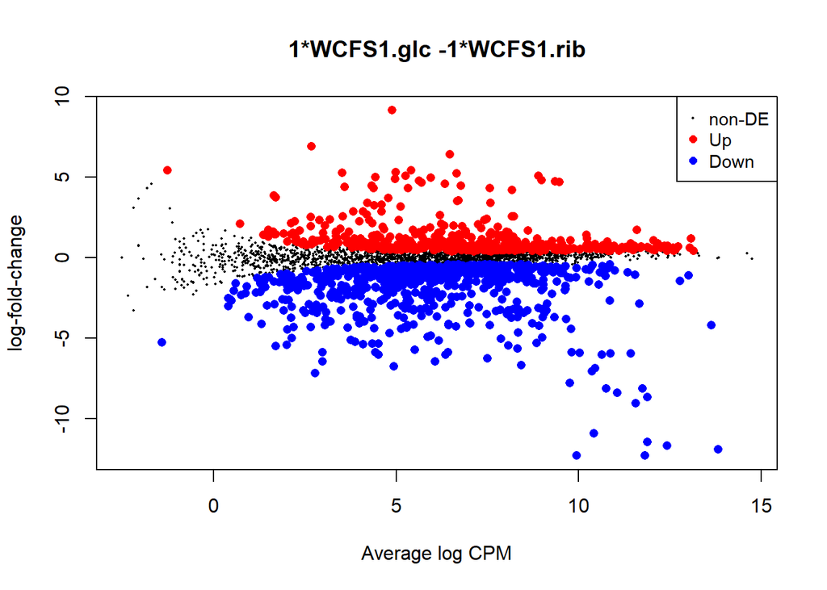

```r
plotMD(fit)
```

```r
summary(decideTests(fit))
```

```
##        1*WCFS1.glc -1*WCFS1.rib
## Down                        677
## NotSig                     1892
## Up                          488
```

# maakt subset van differentialy expressed genes write.table(sub, file = “sub.txt”)

write.csv(comp2, file = “MyData.csv”,row.names=FALSE) only significant so pvalue lower than 0.05 no low fold change so lower than -2 or higher than 2

```r
DE_Genes<- fit$table[which(fit$table$PValue < 0.05), names(fit$table) %in% c("logFC","LogCPM","LR","PValue")]
DE_Genes<- DE_Genes[which(DE_Genes$logFC < -2 | DE_Genes$logFC > 2), names(DE_Genes) %in% c("logFC","LR","PValue")]
```

# joint de annotatie file met de DE_genes

```r
library(dplyr)
names1 <- row.names(DE_Genes)
names2 <- DE_Genes[1]
names <- data.frame(genes = names1, Foldchange = names2 )
comp <- merge(WCFS1_anno,names, by.x = "ORF",by.y = "genes")
```

# maakt een lijst met alle EC nummers en haalt alles zonder eruit

```r
sub <- select(filter(comp, comp$EC != ""),c("EC"))
comp2 <- semi_join(comp,sub, by = c("EC" = "EC"))
```

# schrijft data weg naar een file

```r
write.table(sub, file = "sub.txt")
write.csv(comp2, file = "MyData.csv",row.names=FALSE)
```